# Building a Prediction Model

Using Regression Models to Predict Soil Moisture in Southeaster United States

Zeshen Li *[UCSB Winter 2026]

## Introduction

### Research background and aim of the project

The Southeastern United States contains many lakes, streams, and reservoirs that serve as important sources of drinking water and support recreational, agricultural, and ecological activities. The region also has a large number of impounded rivers. Historically, large reservoir systems in the southeast have been managed for flood control, commerce, hydropower generation, recreation, and drinking water supply. In addition, urban areas and new developments increasingly use retention and detention ponds to control stormwater runoff from nonpoint sources.

While these water management strategies are intended to conserve and regulate water resources, their implementation—combined with the naturally water-rich conditions of the region—has produced several unintended hydrological consequences. One such consequence is the observed increase in soil moisture levels across parts of the Southeast.

This research project aims to analyze the influence of selected streamflow components on soil moisture dynamics using statistical and computational modeling approaches derived from the PRMS (Precipitation–Runoff Modeling System). By examining these relationships, the study seeks to construct predicting models that are able to predict soil moisture values based on existing streamflow components and statistics collected through local hydrological observation station, and provide insights into potential hydrological and geomorphological changes in the Southeastern United States, including the identification of areas that may be susceptible to soil cracking, erosion, or other forms of terrain instabilities resulting from persistent soil saturation.

[figure not shown]

Fig.1 surface soil moisture of the southeastern United States. It is known that various factors on the ground, including high soil moisture, play important roles in terrain instabilities. Source:https://www.drought.gov/data-maps-tools/groundwater-and-soil-moisture-conditions-grace-data-assimilation

### Introduction to a hydrological modeling system

Before we introducing the data used for this research project and learn its statistical implications, we need to introduce the PRMS. PRMS is the shorthand for ‘Precipitation Runoff Modeling System,’ a modeling system developed by the USGS(United States Geological Survey) to ‘evaluate the response of various combinations of climate and land use on streamflow and general watershed hydrology.’

*[the official page for PRMS: https://www.usgs.gov/software/precipitation-runoff-modeling-system-prms ]*

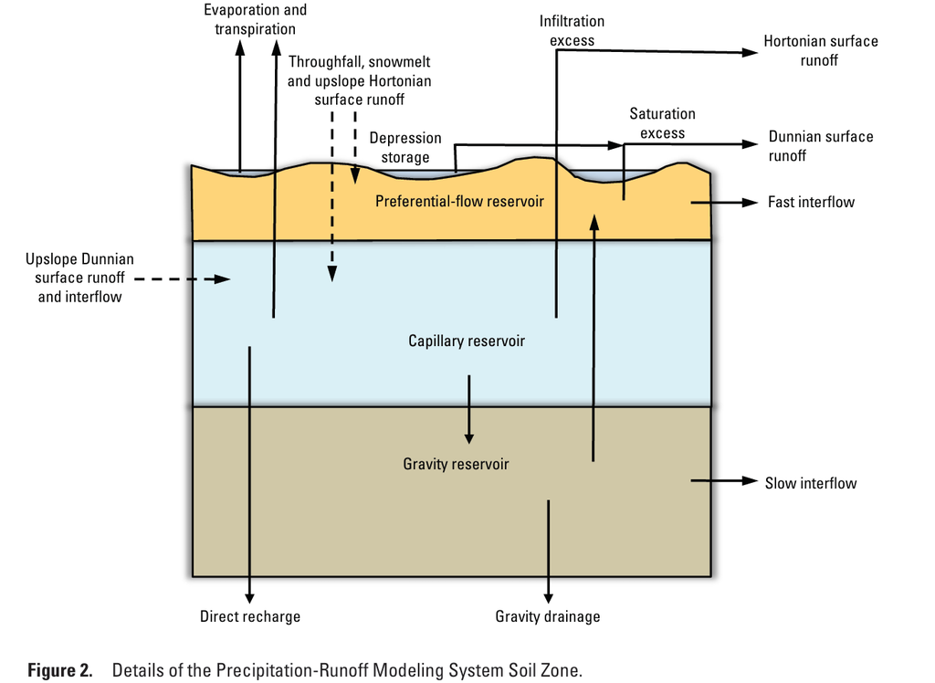

Fig.2 the conceptual structure of the Precipitation-Runoff Modeling System Soil Zone. Labelled originally as Figure 2. in the PRMS instruction manual, it shows how the model divided the soil zone into various components for statistical recordings and analysis

### Source data and its issues

We now load the data imported from the source on official USGS government website. The link to the webpage is provided below: https://www.sciencebase.gov/catalog/item/597b37bbe4b0a38ca27563d4.

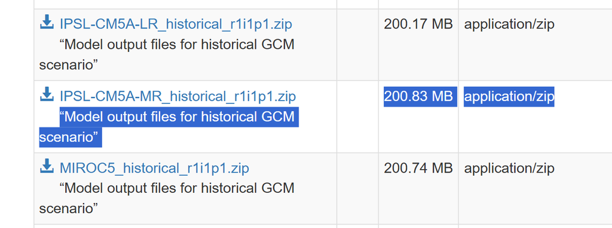

Fig.3 The data zip file itself is among the numerous files located under a child item, ‘Precipitation Runoff Modeling System Output Data from Hydrologic Simulations of the Southeastern United States for Historical and Future Conditions’, of the parent data set ‘Model Input and Output for Hydrologic Simulations of the Southeastern United States for Historical and Future Conditions.’ They document the input to and output from the Precipitation Runoff Modeling System models developed for a U.S. Geological Survey Scientific Investigations Report LaFontaine and others (2019).

This dataset belongs to the historical and potential future simulations of streamflow statistics for the southeastern United States; specifically, **it is part of the 13 historical climate simulations datasets (from the southeastern United States) for the period 1950-2005**, using statistically downscaled general circulation model (GCM) output from the Coupled Model Intercomparison Project (CMIP5).

Of the 13 datasets, only this dataset is selected for this project.

- Name of this dataset’s root zip file: IPSL-CM5A-MR_historical_r1i1p1.zip

  Meaning: the data belongs to one of the 13 ‘model output files for historical GCM scenario’, and was collected by Institut Pierre-Simon Laplace in France.
- Name of this dataset: prms_summaryDyn

  Meaning: ‘summary dynamics’ for the collected PRMS data

We first examine the format and contents of the original excel spreadsheet, and immediately notice several uncommon features in it (likely attributable to outdated data recording conventions):

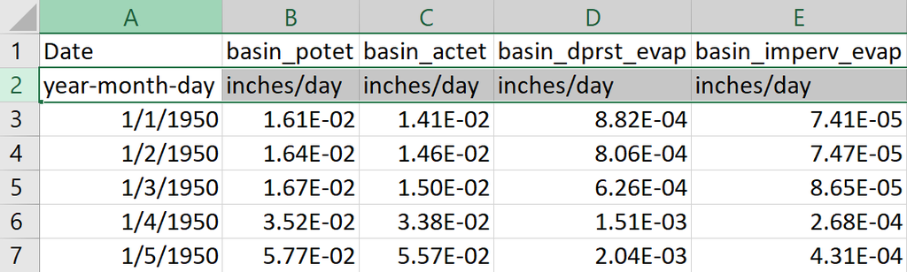

Fig.3 screenshot of the problematic original spreadsheet

- 1.The second row consisted entirely of units expressed as text, rather than numerical data, which could bring complications to calculations in R.
- 2.Numerous cells in the spreadsheet contained the exact value -999, particularly in the last column, `runoff_cfs`. Given that runoff_cfs is defined as the streamflow gage observations in cubic feet per second, negative values are physically impossible. We therefore deduced that here -999 likely served as a placeholder for missing or null values, which is now often considered a outdated practice.

The second row was therefore manually deleted outside of RStudio to prevent any possible confusions. The resulting file, prms_summaryDyn_new.xlsx, was subsequently imported for further analysis. These remaining issues were addressed within the RStudio environment. Unit information and other relevant metadata were documented and stored in a separate file named prms_attributes.xlsx, which will be submitted along with the final project.

After the spreadsheet format was updated, we import and check the data.

## 1. Exploratory Data Analysis

### 1.01 Cleaning Data and choosing variables of interest

We first import the data, and tidy it by removing rows and columns that does not fit the modern excel spreadsheet format.

```r
## data showcases
surfaceWaterStat <- read_csv('data/prms_summaryDyn_new.csv')
surfaceWaterStat %>%
  head()
```

```
## # A tibble: 6 × 52
##   Date     basin_potet basin_actet basin_dprst_evap basin_imperv_evap
##   <chr>          <dbl>       <dbl>            <dbl>             <dbl>
## 1 1/1/1950      0.0161      0.0141         0.000882         0.000074
## 2 1/2/1950      0.0164      0.0146         0.000806         0.0000747
## 3 1/3/1950      0.0167      0.015          0.000626         0.0000865
## 4 1/4/1950      0.0352      0.0338         0.00151          0.000268
## 5 1/5/1950      0.0577      0.0557         0.00204          0.000431
## 6 1/6/1950      0.0608      0.0582         0.00225          0.000252
## # ℹ 47 more variables: basin_intcp_evap <dbl>, basin_lakeevap <dbl>,
## #   basin_perv_et <dbl>, basin_snowevap <dbl>, basin_swrad <dbl>,
## #   basin_ppt <dbl>, basin_pk_precip <dbl>, basin_tmax <dbl>, basin_tmin <dbl>,
## #   basin_snowcov <dbl>, basin_total_storage <dbl>,
## #   basin_surface_storage <dbl>, basin_dprst_volcl <dbl>,
## #   basin_dprst_volop <dbl>, basin_gwstor <dbl>, basin_imperv_stor <dbl>,
## #   basin_intcp_stor <dbl>, basin_lake_stor <dbl>, basin_pweqv <dbl>, …
```

```r
### identify which columns contain only zeros
which(colSums(surfaceWaterStat == 0)
      == nrow(surfaceWaterStat)
)
```

```
##          basin_lakeevap       basin_dprst_volcl         basin_lake_stor
##                       7                      18                      23
##            basin_gwsink           basin_dunnian            basin_dnflow
##                      38                      42                      46
## basin_gwstor_minarea_wb
##                      47
```

```r
### remove those zero columns and create a new dataframe
### also remove runoff_cfs, whose ancient recording conventions contains numerous -999 as placeholder
### also remove Date, so the correlation plot can exist normally
surfaceWaterStat_nonzero <- surfaceWaterStat %>%
    select(where(~ any(. != 0)))

surfaceWaterStat_nonzero$runoff_cfs <- NULL
surfaceWaterStat_nonzero$Date <- NULL

summary(surfaceWaterStat_nonzero)
```

```
##   basin_potet       basin_actet      basin_dprst_evap   basin_imperv_evap
##  Min.   :0.00692   Min.   :0.00578   Min.   :0.000106   Min.   :9.820e-08
##  1st Qu.:0.06140   1st Qu.:0.04480   1st Qu.:0.001690   1st Qu.:8.940e-05
##  Median :0.11700   Median :0.07010   Median :0.002730   Median :2.590e-04
##  Mean   :0.11527   Mean   :0.07580   Mean   :0.002862   Mean   :2.747e-04
##  3rd Qu.:0.16800   3rd Qu.:0.10400   3rd Qu.:0.004020   3rd Qu.:4.410e-04
##  Max.   :0.23500   Max.   :0.19600   Max.   :0.006430   Max.   :7.500e-04
##  basin_intcp_evap   basin_perv_et     basin_snowevap       basin_swrad
##  Min.   :0.000000   Min.   :0.00417   Min.   :0.000e+00   Min.   : 87.2
##  1st Qu.:0.000145   1st Qu.:0.04060   1st Qu.:0.000e+00   1st Qu.:260.0
##  Median :0.000726   Median :0.06510   Median :0.000e+00   Median :392.0
##  Mean   :0.001638   Mean   :0.07098   Mean   :4.440e-05   Mean   :377.8
##  3rd Qu.:0.002220   3rd Qu.:0.09830   3rd Qu.:1.768e-07   3rd Qu.:501.0
##  Max.   :0.015500   Max.   :0.19000   Max.   :2.240e-03   Max.   :603.0
##    basin_ppt         basin_pk_precip      basin_tmax      basin_tmin
##  Min.   :0.0000141   Min.   :0.000000   Min.   : 24.4   Min.   : 1.36
##  1st Qu.:0.0106000   1st Qu.:0.000000   1st Qu.: 63.2   1st Qu.:38.30
##  Median :0.0543000   Median :0.000000   Median : 77.3   Median :52.30
##  Mean   :0.1095514   Mean   :0.004917   Mean   : 74.9   Mean   :50.56
##  3rd Qu.:0.1550000   3rd Qu.:0.000111   3rd Qu.: 88.2   3rd Qu.:64.80
##  Max.   :1.2000000   Max.   :0.754000   Max.   :102.0   Max.   :75.90
##  basin_snowcov     basin_total_storage basin_surface_storage basin_dprst_volop
##  Min.   :0.00000   Min.   : 1.340      Min.   :0.00118       Min.   :0.000816
##  1st Qu.:0.00000   1st Qu.: 5.380      1st Qu.:0.05000       1st Qu.:0.037900
##  Median :0.00000   Median : 7.990      Median :0.08740       Median :0.073100
##  Mean   :0.03091   Mean   : 7.835      Mean   :0.12856       Mean   :0.086544
##  3rd Qu.:0.00145   3rd Qu.:10.300      3rd Qu.:0.14600       3rd Qu.:0.122000
##  Max.   :0.90000   Max.   :17.100      Max.   :2.88000       Max.   :0.341000
##   basin_gwstor    basin_imperv_stor   basin_intcp_stor     basin_pweqv
##  Min.   : 0.586   Min.   :0.000e+00   Min.   :0.0000172   Min.   :0.0000000
##  1st Qu.: 3.340   1st Qu.:4.650e-07   1st Qu.:0.0073500   1st Qu.:0.0000000
##  Median : 5.580   Median :4.860e-07   Median :0.0137000   Median :0.0000000
##  Mean   : 5.757   Mean   :3.268e-05   Mean   :0.0118506   Mean   :0.0301357
##  3rd Qu.: 8.390   3rd Qu.:1.600e-05   3rd Qu.:0.0169000   3rd Qu.:0.0003635
##  Max.   :11.400   Max.   :6.320e-04   Max.   :0.0200000   Max.   :2.6100000
##  basin_soil_moist  basin_ssstor     basin_pref_stor    basin_slstor
##  Min.   :0.342    Min.   :0.01270   Min.   :0.00168   Min.   :0.00865
##  1st Qu.:1.260    1st Qu.:0.04760   1st Qu.:0.00818   1st Qu.:0.03830
##  Median :1.860    Median :0.08100   Median :0.01010   Median :0.07080
##  Mean   :1.852    Mean   :0.09809   Mean   :0.01044   Mean   :0.08766
```

[output cut: 29 more lines]

```
##  Max.   :0.3680000   Max.   :0.1890000   Max.   :0.57700   Max.   :0.164000
##   basin_gwflow       basin_cfs       basin_gwflow_cfs basin_sroff_cfs
##  Min.   :0.00132   Min.   :   5210   Min.   : 15900   Min.   :      1.2
##  1st Qu.:0.00588   1st Qu.: 151000   1st Qu.: 70700   1st Qu.:   4740.0
##  Median :0.01200   Median : 316000   Median :145000   Median :  26600.0
##  Mean   :0.01486   Mean   : 383118   Mean   :178415   Mean   : 102811.4
##  3rd Qu.:0.02100   3rd Qu.: 530000   3rd Qu.:252000   3rd Qu.: 107000.0
##  Max.   :0.06520   Max.   :1980000   Max.   :783000   Max.   :2270000.0
##  basin_ssflow_cfs
##  Min.   :   2430
##  1st Qu.:  17000
##  Median :  35600
##  Mean   : 116708
##  3rd Qu.:  93300
##  Max.   :4470000
```

```r
ncol(surfaceWaterStat_nonzero)
```

```
## [1] 43
```

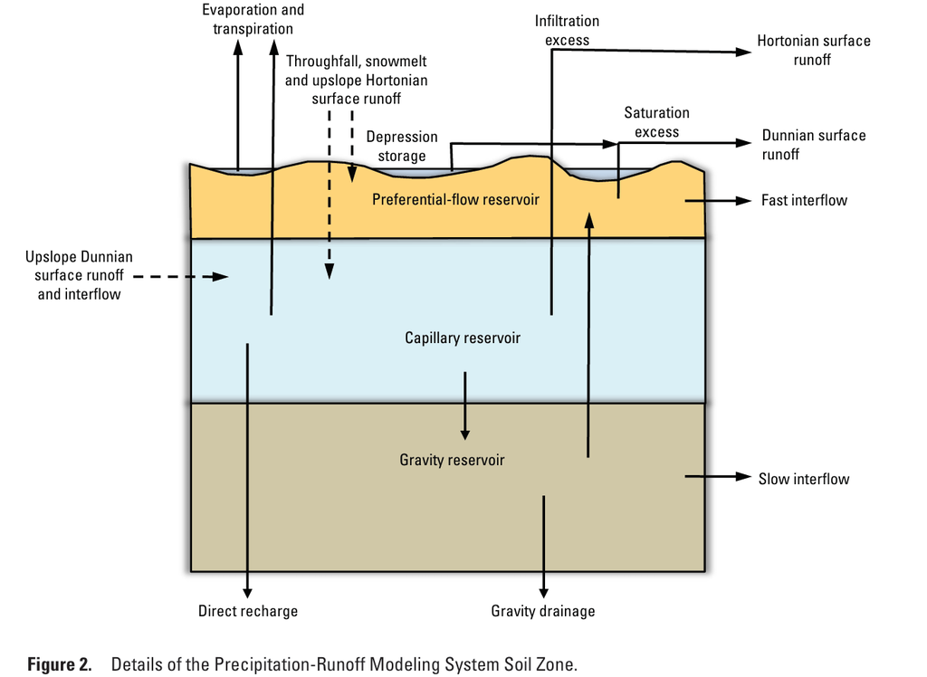

Fig.2 the conceptual structure of the Precipitation-Runoff Modeling System Soil Zone. Labelled originally as Figure 2. in the PRMS instruction manual, it shows how the model divided the soil zone into various components for statistical recordings and analysis

We present Figure 2 once again. As can be seen from fig.2 the two primary pathways for capillary reservoir to shed off excess water that exceeds its capacity into the air are: 1. evaporation and transpiration (often collectively abbreviated as *ET*, i.e., evapotranspiration) and 2. infiltration excess. Infiltration excess comes from the rate of rainfall or snowmelt that is greater than the infiltration capacity. Since this process is more directly associated with the preferential-flow reservoir than with the capillary reservoir we are concerned about, and and varies greatly due to local conditions, which may introduce noises and outliers to the data, we choose to focus on evaporation and transpiration processes instead, which bring us to two new key variables: `basin_potet` and `basin_actet`.

- `basin_potet`: Basin area-weighted average potential evapotranspiration (ET).
- `basin_actet`: Basin area-weighted average actual evapotranspiration.

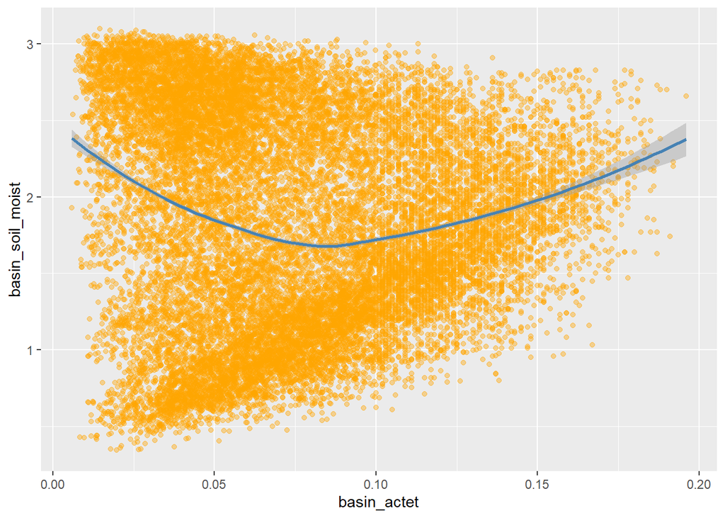

```r
ggplot(surfaceWaterStat_nonzero, aes(x = basin_actet, y = basin_soil_moist)) +
  geom_point(alpha = 0.4, color = "orange") +
  geom_smooth(method = "loess", color = "steelblue")
```

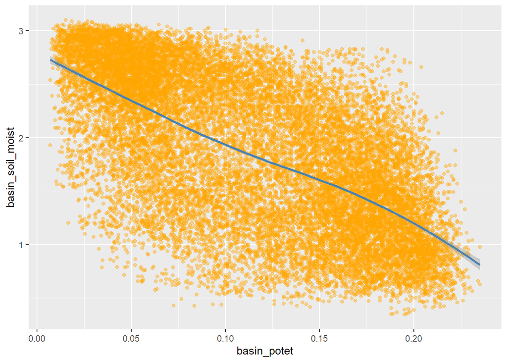

```r
ggplot(surfaceWaterStat_nonzero, aes(x = basin_potet, y = basin_soil_moist)) +
  geom_point(alpha = 0.4, color = "orange") +
  geom_smooth(method = "loess", color = "steelblue")
```

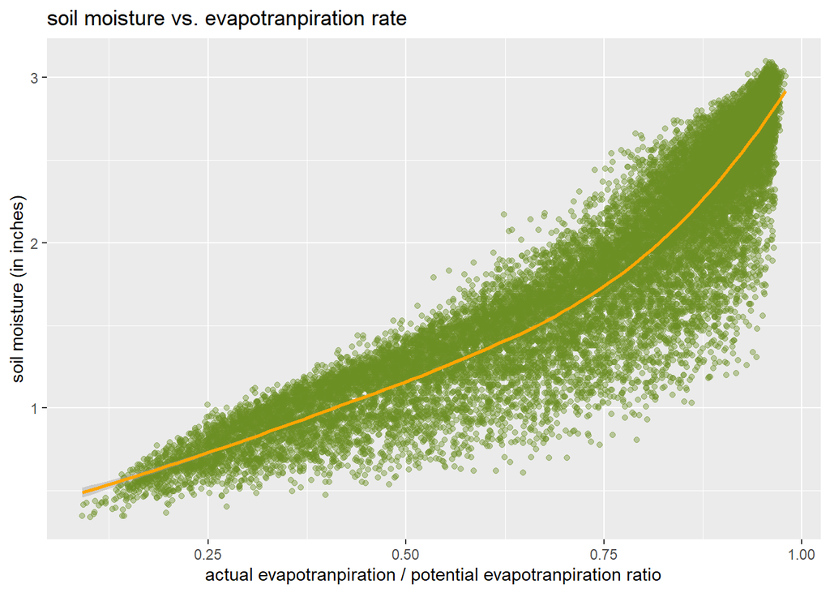

```r
df_et <- surfaceWaterStat_nonzero %>%
  mutate(moisture_ratio = basin_soil_moist / max(basin_soil_moist),
         et_efficiency = basin_actet / basin_potet)

ggplot(df_et, aes(x = et_efficiency, y = basin_soil_moist)) +
  geom_point(alpha = 0.4, color = "olivedrab") +
  geom_smooth(method = "loess", color = "orange") +
  labs(title = "soil moisture vs. evapotranpiration rate",
       x = "actual evapotranpiration / potential evapotranpiration ratio",
       y = "soil moisture (in inches)"
       )
```

We are able to see a strong, positive, yet non-linear correlation, with a high amount of spread of variances across the curve, indicating that as actual evapotranspiration rate approaches potential evapotranspiration rate, soil moisture shows an accelerated rate of increase.

### 1.02 Finding the predictors

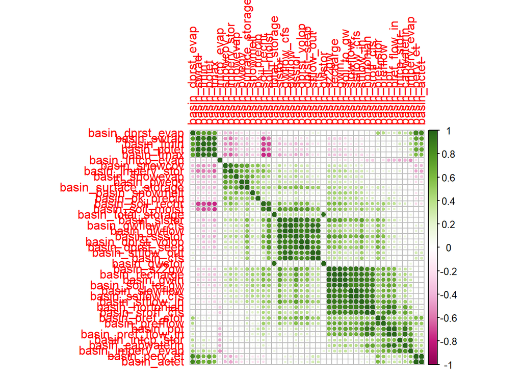

```r
corr_trix_1 <- cor(surfaceWaterStat_nonzero)
corrplot(corr_trix_1,
         order = 'AOE',
         col = COL2("PiYG")
         )
```

The variables are packed together, so lets export the graph with higher resolution and import it back to the document:

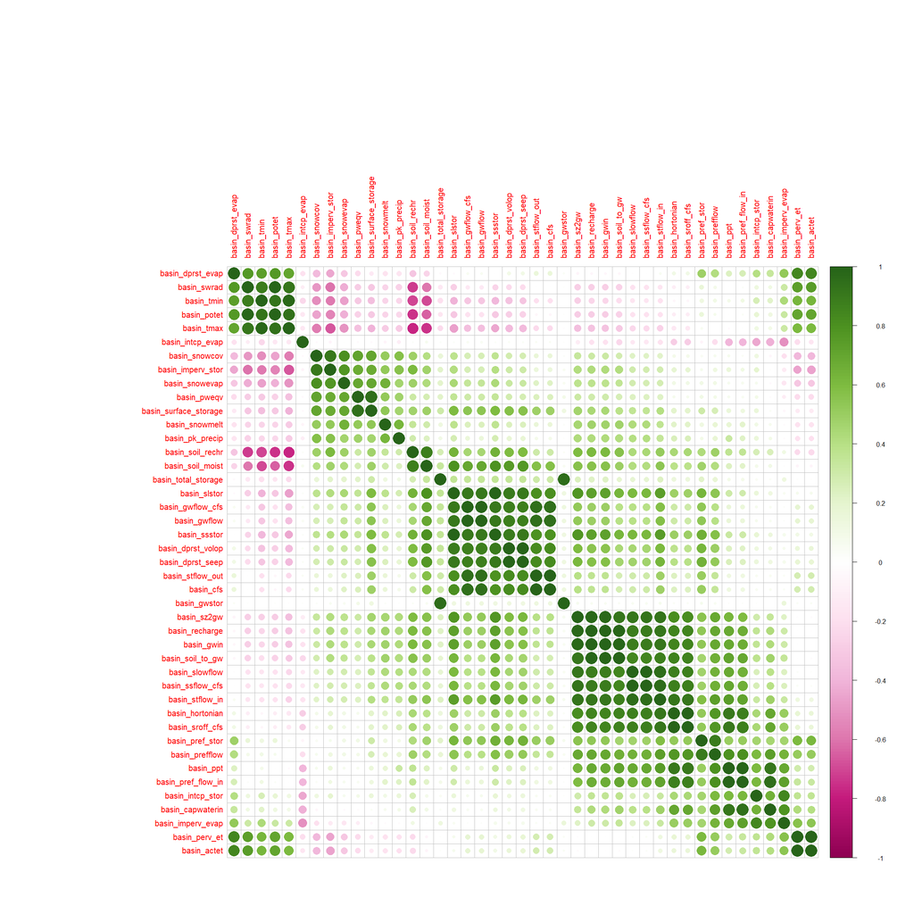

Fig.4 the full correlation plot

The correlation plot does the job nicely. We also notice there are way too many variables that have little to do with `basin_soil_moist`.

Previously we stated our interest in focusing on finding the best predictors for `basin_soil_moist`, based on the assumption that as actual evapotranspiration rate approaches potential evapotranspiration rate, soil moisture shows an accelerated rate of increase. Based on this correlation plot, we managed to find correlations that stand out towards these 3 variables:

- for basin_actet: there are moderately positive correlations between it and basin_dprst_evap, as well as basin_perv_et;
- for basin_potet: there are moderately positive correlations between it and basin_swrad basin_tmin, as well as basin_tmax;
- for basin_soil_moist: there are moderately positive correlation between it and basin_soil_rechr, and a highly degative correlation between it and basin_tmax.

Although numerous positive correlations can be identified, this seemingly complex relationship can be explained by reviewing that in the conceptual structure of the modeling system(Fig.2), water originating from precipitation (such as rain) or surface flow can migrate between layers through processes such as infiltration, transpiration and evaporation, This mechanism accounts for the observation that while correlations exist between basin_soil_moist (a variable representing capillary reservoirs) and other variables with little direct connection to evapotranspiration—such as various forms of surface storage—these correlations tend to be only weakly positive. We should set aside these only slightly related correlations and instead focusing on the stronger, more important correlations.

### 1.03 Describing the predictors

The variables that I will be using in my model recipe are as following: * `basin_potet`: Basin area-weighted average potential ET(evapotranspiration). * `basin_actet`: Basin area-weighted average actual ET. * `basin_swrad`: Basin area-weighted average shortwave radiation. * `basin_tmin`: Basin area-weighted average minimum air temperature. * `basin_tmax`: Basin area-weighted average maximum air temperature. * `basin_dprst_evap`: Basin area-weighted average evaporation from surface-depression storage. * `basin_perv_et`: Basin area-weighted average ET from capillary reservoirs. * `basin_soil_rechr`: Basin area-weighted average storage for recharge zone; upper portion of capillary reservoir where both evaporation and transpiration occurs. * `basin_soil_moist`: Basin area-weighted average capillary reservoir storage.

```r
surfaceWaterStat_nonzero <- surfaceWaterStat_nonzero %>%
  select(c("basin_potet", "basin_actet", "basin_dprst_evap",  "basin_perv_et", "basin_swrad", "basin_tmax", "basin_tmin", "basin_soil_rechr", "basin_soil_moist")) %>%
  clean_names()
```

We remove the unwanted variables and the final dataset is now complete.

### 1.04 Exploring the features of predictors

We now plot a histogram to see the frequency distribution of the soil moisture.

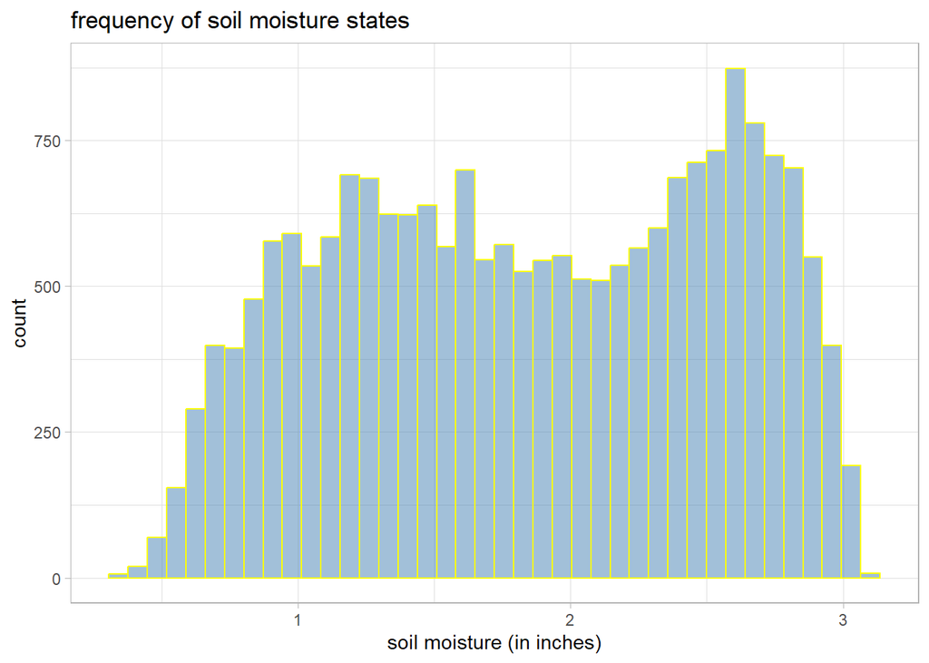

```r
ggplot(surfaceWaterStat_nonzero, aes(x = basin_soil_moist)) +
  geom_histogram(bins = 40, fill = "steelblue", color = "yellow", alpha = 0.5) +
  labs(title = "frequency of soil moisture states",
       x = "soil moisture (in inches)") +
  theme_light()
```

As seen above, the histogram with two distinct peaks is slightly left-skewed, which indicates that conditions that leads to high soil moisture were happening more frequently in the region, and that local hydrological variabilities across the year, such as seasonal changes or the presence of intermittent rivers, may explain the difference in peak soil moisture readings throughout the year. How interesting and complicated!

We also plot two histograms to see the frequency distribution of potential or actual evapotranspiration rates.

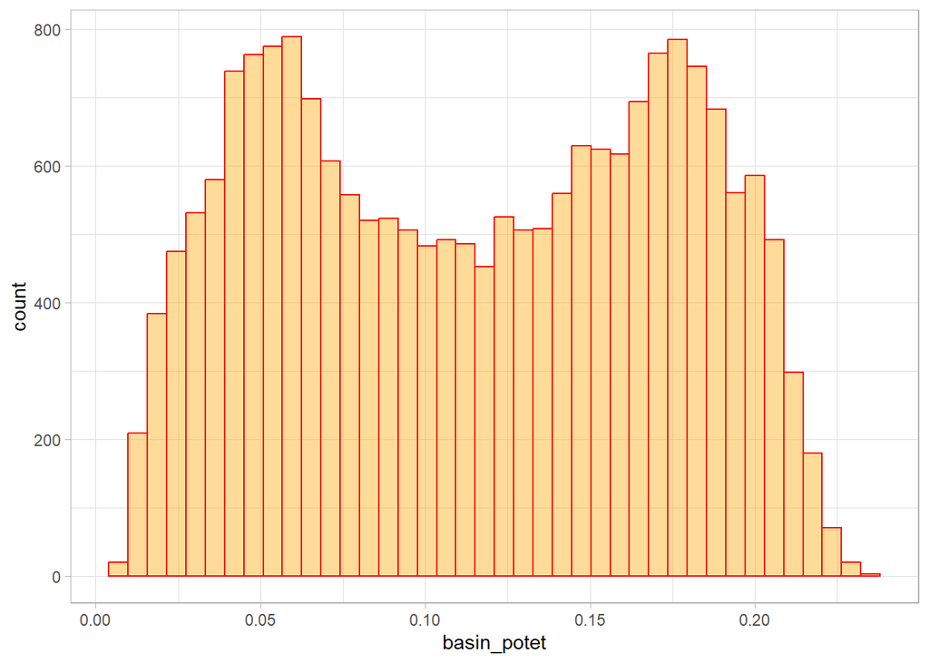

```r
ggplot(surfaceWaterStat_nonzero, aes(x = basin_potet)) +
  geom_histogram(bins = 40, fill = "orange", color = "red", alpha = 0.4) +
  theme_light()
```

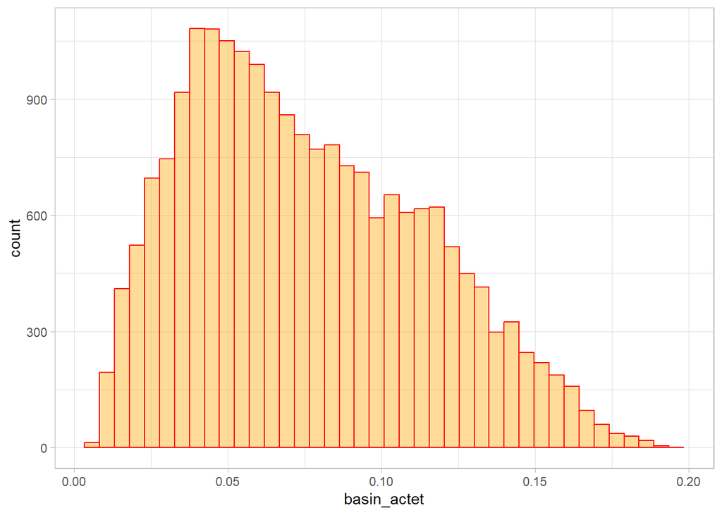

```r
ggplot(surfaceWaterStat_nonzero, aes(x = basin_actet)) +
  geom_histogram(bins = 40, fill = "orange", color = "red", alpha = 0.4) +
  theme_light()
```

## 2. Setting Up Models

### 2.01 Data split

The first step we have to take before fitting any models is splitting our data into a training and testing set. The training set will be used to train our models. The testing set acts as a test in the sense that our models will not be able to train on that data. By splitting our data into testing and training sets, we avoid over-fitting because the model is not using all of the available data to learn.

The split I have chosen is a 80/20 split, which means 80% of the data will go towards the training set and 20% of the data will go towards the testing set. This way, most of our data is being used to train the model and we would still have an adequate amount of data to test the model on. Also, the split is stratified on the variable basin_soil_moist, which is what we are aiming to ‘predict’ based on the evapotranspiration rate ratio, to ensure that both the training and the testing data have an equal distribution of basin_soil_moist.

```r
## 80%
set.seed(123)
stat_split <- initial_split(
  surfaceWaterStat_nonzero,
  prop=0.8,
  strata=basin_soil_moist
  )
stat_train <- training(stat_split)
stat_test <- testing(stat_split)
```

We now conduct a simple verification on the splitting ratio.

```r
nrow(stat_train)/nrow(stat_test)
```

```
## [1] 3.998045
```

```r
nrow(stat_test)/nrow(stat_train)
```

```
## [1] 0.2501222
```

The result shows roughly 4 and 0.25, which means we did the 80/20 split correctly.

### 2.02 Building recipe and K-fold cross validation

```r
# creating recipte
capillaryReservoirs_recipe <- recipe(basin_soil_moist ~ basin_actet + basin_potet + basin_dprst_evap + basin_perv_et + basin_swrad + basin_tmin + basin_tmax + basin_soil_rechr,
                                     data = stat_train) %>%
  step_dummy(all_nominal(), one_hot = TRUE) %>%
  step_mutate( et_efficiency =
                 basin_actet / basin_potet) %>%
  step_center(all_predictors()) %>%
  step_scale(all_predictors())

# creating folds
stat_folds <- vfold_cv(stat_train, v = 10, strata = basin_soil_moist)
```

We will now bring together our predictors and our response variable to build our recipe which we will use for all the models, and stratify our cross validation on our response variable, basin_soil_moist.

previously we managed to find correlations that stand out towards 3 variables that we care the most:

- for basin_actet: there are moderately positive correlations between it and basin_dprst_evap, as well as basin_perv_et;
- for basin_potet: there are moderately positive correlations between it and basin_swrad basin_tmin, as well as basin_tmax;
- for basin_soil_moist: there are moderately positive correlation between it and basin_soil_rechr, and a highly degative correlation between it and basin_tmax.

Therefore, we will be using 8 out of our 51 predictor variables in our recipe, excluding Date, which is not a numerical value. while it is unreasonable to claim the excluded 43 predictors exert no influence whatsoever on the selected variables, we have learned both from the conceptual structure and the correlation plot that the correlations these variables provided are simply nor strong enough.

## 3. Model Building

### 3.01 Fitting the model

For each model, we must execute the following steps to perform the fitting process:

1. Specify the specific model, the parameters requiring tuning, the underlying model engine, and the execution mode.
2. Configure a Workflow for the model, integrating the model object with the preprocessing Recipe.
3. Define the value ranges for the parameters and specify the number of levels to be included for each parameter.
4. Specify the workflow to be tuned, the number of folds for K-fold cross-validation, and the tuning grid defined for the selected parameters.
5. Save the tuned model to an RDS file to avoid the need to rerun the model in the future; subsequently, reload the previously saved file.
6. Sort the results in ascending order by mean to identify the lowest RMSE value achievable by the model; next, perform a slicing operation to extract only this minimum RMSE value. Finally, store this RMSE value in a variable for use in subsequent comparative analyses.

```r
# 1. KNN
knn_model_001 <- nearest_neighbor(
  neighbors = tune()
) %>%
  set_mode("regression") %>%
  set_engine("kknn")

workflow_knn001 <- workflow() %>%
  add_model(knn_model_001) %>%
  add_recipe(capillaryReservoirs_recipe)

knn_grid <- grid_regular(
  neighbors(range = c(10, 80)),
  levels = 5
)

knn_tune <- tune_grid(
  workflow_knn001,
  resamples = stat_folds,
  grid = knn_grid,
  metrics = metric_set(rmse, mae, rsq)
)

write_rds(knn_tune, file = "data/tuned_models/knn.rds")
knn_tuned <- read_rds(file = "data/tuned_models/knn.rds")

knn_rmse <- show_best(knn_tuned, metric = "rmse", n = 1)$mean

# 2. gradient boosted tree,
boost_model_002 <- boost_tree(
  trees = tune(),
  min_n = tune(),
  learn_rate = tune()
) %>%
  set_engine("xgboost") %>%
  set_mode("regression")


workflow_boost002 <- workflow() %>%
  add_model(boost_model_002) %>%
  add_recipe(capillaryReservoirs_recipe)

boost_grid <- grid_regular(
  trees(range = c(200, 500)),
  min_n(range = c(2, 20)),
  learn_rate(range = c(0.01,0.1)),
  levels = 5
)

boost_tune <- tune_grid(
  workflow_boost002,
  resamples = stat_folds,
  grid = boost_grid,
  metrics = metric_set(rmse, mae, rsq)
)

write_rds(boost_tune, file = "data/tuned_models/boost.rds")
boost_tuned <- read_rds(file = "data/tuned_models/boost.rds")

boost_rmse <- show_best(boost_tuned, metric = "rmse", n = 1)$mean


# 3. support vector machines,
support_vec_model_003 <- svm_linear(
  cost = tune()
) %>%
  set_engine("kernlab") %>%
  set_mode("regression")

workflow_support003 <- workflow() %>%
  add_model(support_vec_model_003) %>%
  add_recipe(capillaryReservoirs_recipe)

svm_grid <- grid_regular(
  cost(range = c(-4, 1), trans = log10_trans()),
  levels = 10
)


svm_tune <- tune_grid(
  workflow_support003,
  resamples = stat_folds,
  grid = svm_grid,
  metrics = metric_set(rmse, mae, rsq)
)

write_rds(svm_tune, file = "data/tuned_models/svm.rds")
svm_tuned <- read_rds(file = "data/tuned_models/svm.rds")

svm_rmse <- show_best(svm_tuned, metric = "rmse", n = 1)$mean


# 4. a neural network.
neural_model_004 <- mlp(
  hidden_units = tune(),
  penalty = tune(),
  epochs = tune()
) %>%
  set_engine("nnet") %>%
  set_mode("regression")


workflow_neural004 <- workflow() %>%
  add_model(neural_model_004) %>%
  add_recipe(capillaryReservoirs_recipe)

neural_grid <- grid_regular(
  hidden_units(range = c(1, 10)),
  penalty(range = c(-3, -1)),
  epochs(range = c(20, 100)),
  levels = 5
)

neural_tune <- tune_grid(
  workflow_neural004,
  resamples = stat_folds,
  grid = neural_grid,
  metrics = metric_set(rmse, mae, rsq)
)

write_rds(neural_tune, file = "data/tuned_models/neural.rds")
neural_tuned <- read_rds(file = "data/tuned_models/neural.rds")

neural_rmse <- show_best(neural_tuned, metric = "rmse", n = 1)$mean


# 5. Pruned Decision Tree
tree_model_005 <- decision_tree(
  cost_complexity = tune(),
  tree_depth = tune(),
  min_n = tune()
) %>%
  set_engine("rpart") %>%
  set_mode("regression")

workflow_tree005 <- workflow() %>%
  add_model(tree_model_005) %>%
  add_recipe(capillaryReservoirs_recipe)

tree_grid <- grid_regular(
  cost_complexity(range = c(-5, -2), trans = log10_trans()),
  tree_depth(range = c(2, 10)),
  min_n(range = c(5, 30)),
  levels = 5
)

tree_tune <- tune_grid(
  workflow_tree005,
  resamples = stat_folds,
  grid = tree_grid,
  metrics = metric_set(rmse, mae, rsq)
)

write_rds(tree_tune, "data/tuned_models/tree.rds")
tree_tuned <- read_rds("data/tuned_models/tree.rds")

tree_rmse <- show_best(tree_tuned, metric = "rmse", n = 1)$mean


knn_tuned <- read_rds(file = "data/tuned_models/knn.rds")
knn_rmse <- show_best(knn_tuned, metric = "rmse", n = 1)$mean
boost_tuned <- read_rds(file = "data/tuned_models/boost.rds")
boost_rmse <- show_best(boost_tuned, metric = "rmse", n = 1)$mean
svm_tuned <- read_rds(file = "data/tuned_models/svm.rds")
svm_rmse <- show_best(svm_tuned, metric = "rmse", n = 1)$mean
neural_tuned <- read_rds(file = "data/tuned_models/neural.rds")
neural_rmse <- show_best(neural_tuned, metric = "rmse", n = 1)$mean
tree_tuned <- read_rds("data/tuned_models/tree.rds")
tree_rmse <- show_best(tree_tuned, metric = "rmse", n = 1)$mean
```

## 4. Results of our Models

### 4.01 Bar plot

Now we compare the results of all of our models and see which ones performed the best.

```r
#data frame for all models' RMSEs
all_models <- data.frame(Model = c(
    "KNN",
    "Boosted Trees",
    "SVM",
    "Neural Network",
    "Pruned Decision Tree"
  ),
  RMSE = c(
    knn_rmse,
    boost_rmse,
    svm_rmse,
    neural_rmse,
    tree_rmse
  ))


# tibble chart
final_compare_tibble <- tibble(
  Model = c(
    "KNN",
    "Boosted Trees",
    "SVM",
    "Neural Network",
    "Pruned Decision Tree"),
  RMSE = c(
    knn_rmse,
    boost_rmse,
    svm_rmse,
    neural_rmse,
    tree_rmse)
) %>%
  arrange(RMSE)

final_compare_tibble
```

```
## # A tibble: 5 × 2
##   Model                 RMSE
##   <chr>                <dbl>
## 1 Neural Network       0.198
## 2 KNN                  0.202
## 3 Pruned Decision Tree 0.223
## 4 SVM                  0.235
## 5 Boosted Trees        0.247
```

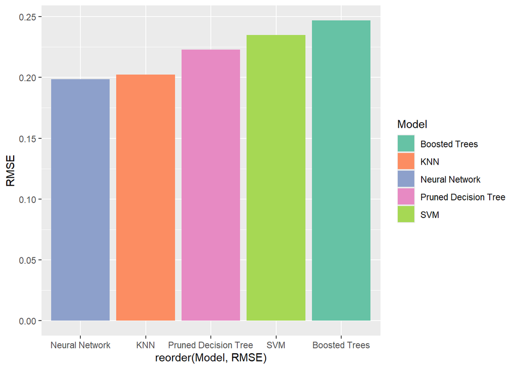

```r
ggplot(all_models, aes(x = reorder(Model, RMSE), y = RMSE)) +
  geom_bar(stat = "identity", aes(fill = Model)) +
  scale_fill_brewer(palette = "Set2")
```

### 4.02 Model autoplots

The autoplot in R allows us to visualize the effect of each of the tuned parameters on the performance of each model. In the autoplots, the performance of the models is measured by the RMSE (the lower the RMSE, the better the model has performed).

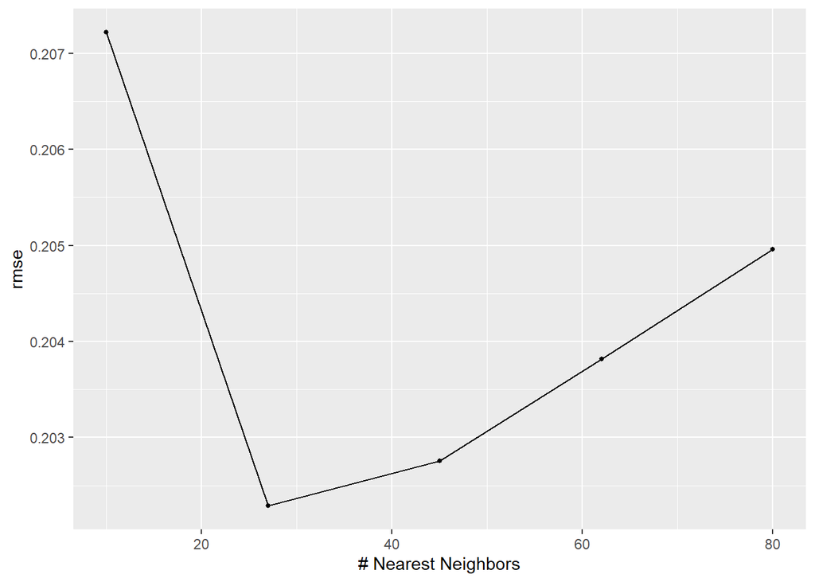

```r
autoplot(knn_tuned, metric = 'rmse')
```

The k-nearest neighbors model displays a general trend that averaging too many data points leads to increase in underfitting. The sharp decline in RMSE on the left side of the plot suggests a brief phase of overfitting; the model is also sensitive to noise and outliers when the number of neighbors is too small. The optimal prediction is at the lowest point on the curve, where the RMSE attains its minimum value.

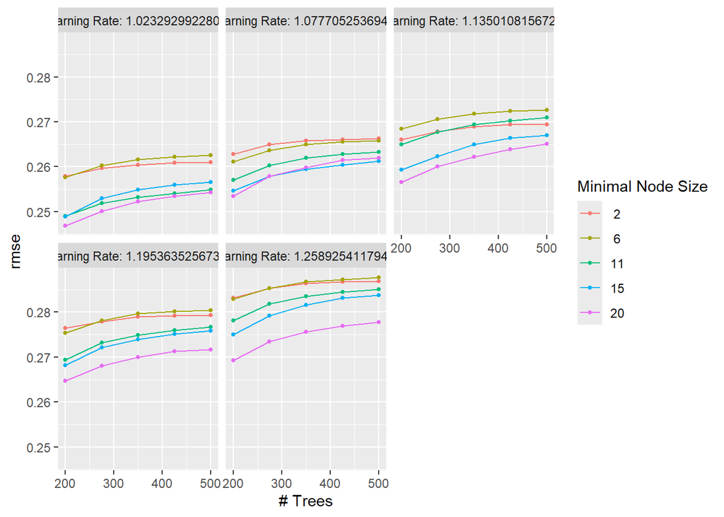

```r
autoplot(boost_tuned, metric = 'rmse')
```

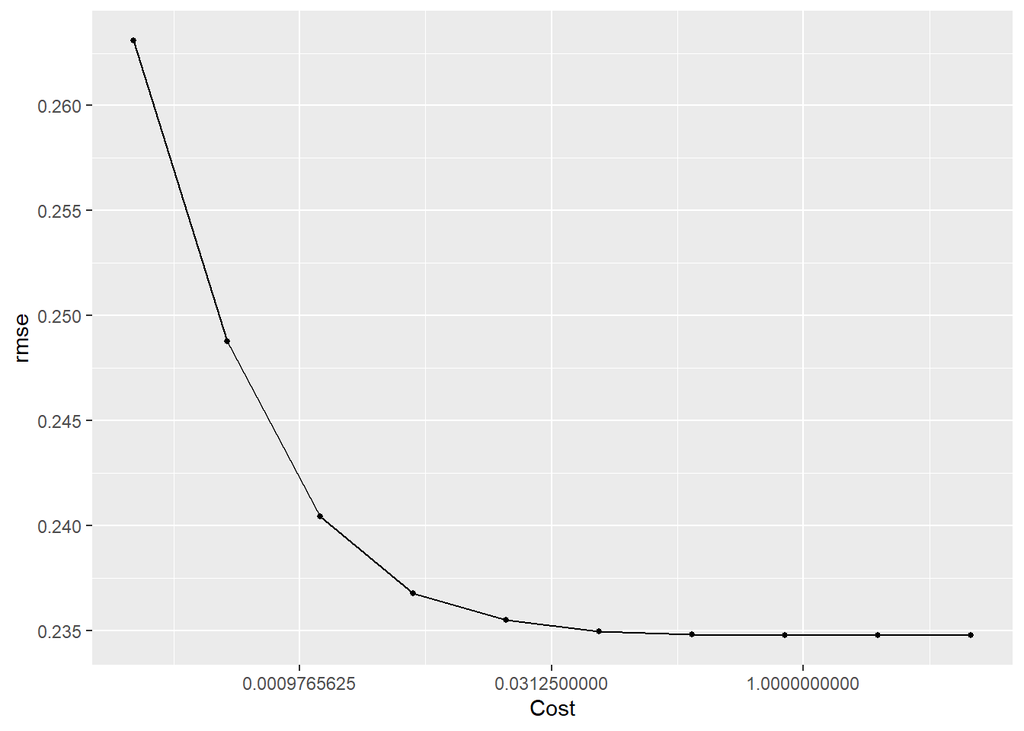

```r
autoplot(svm_tuned, metric = 'rmse')
```

The support vector machine model displays a pattern that shows increase in cost parameter results in decrease in RMSE. This indicates that raising the penalty for misclassified points gets better prediction results. However, the linear SVM appears to reach its maximum predictive capacity once the cost exceeds a certain threshold, and further increases shows no improvement in RMSE. The optimal prediction has a minimum RMSE value of approximately 0.235.

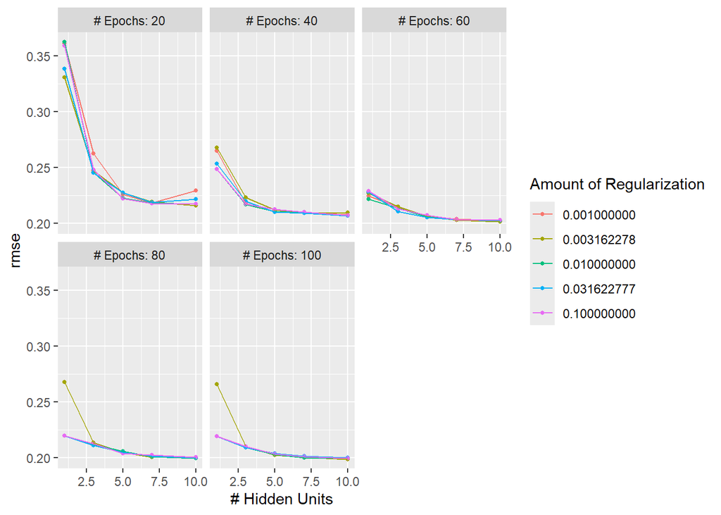

```r
autoplot(neural_tuned, metric = 'rmse')
```

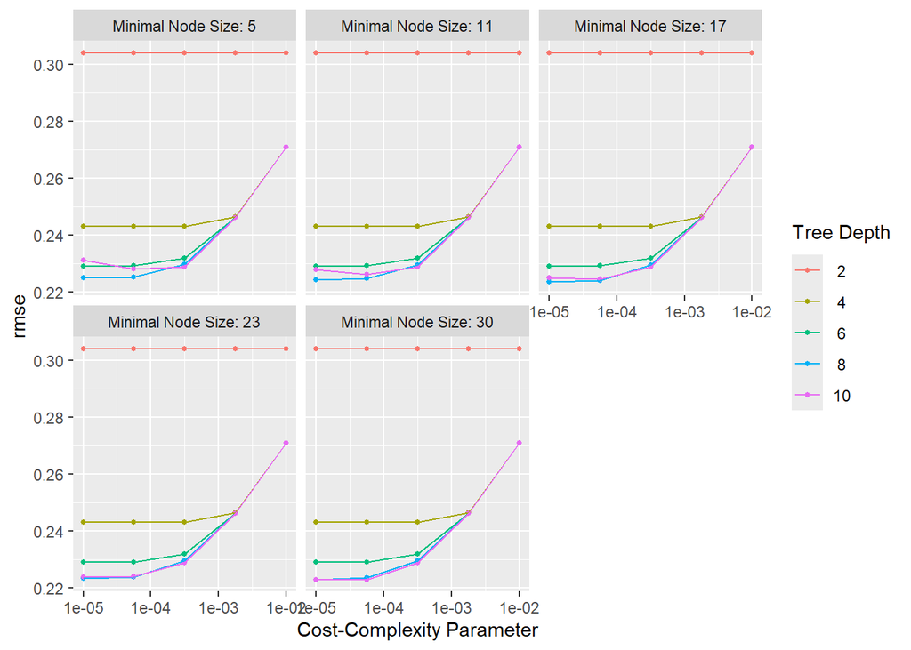

```r
autoplot(tree_tuned, metric = 'rmse')
```

The pruned decision tree model displays a pattern that increasing the cost-complexity parameter leads to higher RMSE due to data underfitting. These trends suggest that to find out the optimal prediction we need to keep the cost-complexity parameter as small as possible. Additionally, a horizontal line is observed for the tree with a depth of 2, since a tree with a depth of 2 can only make a maximum of 3 splits. A depths this low restricts its ability to capture underlying patterns in the data, causing data underfitting that introduces higher RMSE.

## 5. Results From the Best Model

### 5.01 Finding the best model

Based on the previous bar plot, the neural network has the lowest RMSE values. Since we learnt that neural network performed the best among all models, we now focus on finding its best tuned parameters.

```r
best_neural <- neural_tuned %>%
  collect_metrics() %>%
  arrange(mean) %>%
  slice(1)

best_neural
```

```
## # A tibble: 1 × 9
##   hidden_units penalty epochs .metric .estimator  mean     n  std_err .config
##          <int>   <dbl>  <int> <chr>   <chr>      <dbl> <int>    <dbl> <chr>
## 1           10   0.001    100 mae     standard   0.146    10 0.000692 pre0_mod1…
```

### 5.02 Fitting to training data

```r
best_neural_train <- select_best(neural_tuned, metric = 'rmse')
best_neural_train_workflow <- finalize_workflow(
  workflow_neural004, best_neural_train)
best_neural_train_fit <- fit(
  best_neural_train_workflow, data = stat_train)

write_rds(best_neural_train_fit,
          file = "data/final_data/final_train.rds")
```

### 5.03 Testing to training data

```r
best_neural_train_fit <- read_rds(file = "data/final_data/final_train.rds")
final_tibble <- predict(best_neural_train_fit, new_data = stat_test %>% select(-basin_soil_moist))
final_tibble <- bind_cols(final_tibble, stat_test %>% select(basin_soil_moist))

write_rds(final_tibble, file = "data/final_data/final_model.rds")

final_tibble <- read_rds(file = "data/final_data/final_model.rds")
final_metric <- metric_set(rmse)
final_tibble_metrics <- final_metric(final_tibble, truth = basin_soil_moist, estimate = .pred)
final_tibble_metrics
```

```
## # A tibble: 1 × 3
##   .metric .estimator .estimate
##   <chr>   <chr>          <dbl>
## 1 rmse    standard       0.195
```

### 5.04 Plotting

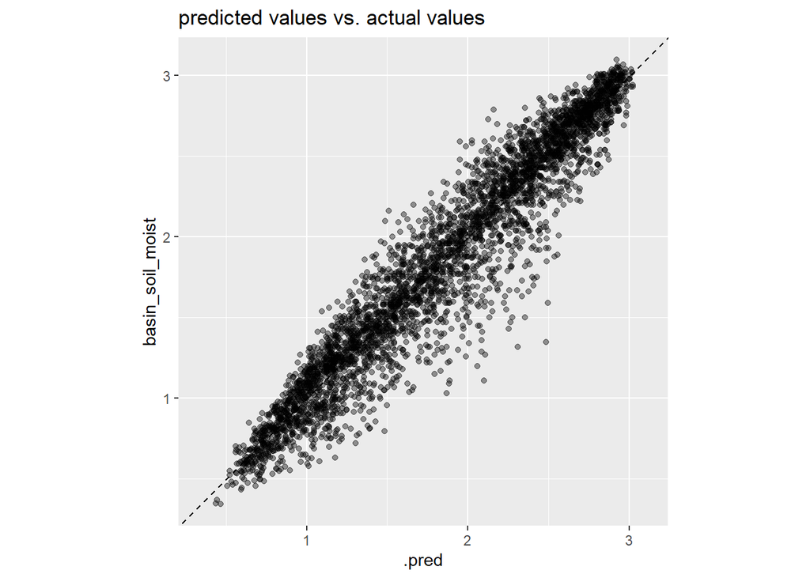

```r
final_tibble %>%
  ggplot(aes(x = .pred, y = basin_soil_moist)) +
  geom_point(alpha = 0.4) +
  geom_abline(lty = 2) +
  theme_grey() +
  coord_obs_pred() +
  labs(title = "predicted values vs. actual values")
```

Based on the plot, the points cluster closely around the line, which indicates that as the actual basin_soil_moist increases, our predictions accurately follow suit. However, the spread of the data points is the widest in the middle of the line.

## 6. Conclusion

The model that did the worst is the boosted trees model. this may has something to do with the boosted trees model’s preconceived notion that a single, dominant trend can be accurately estimated from the provided feature set, while in reality there are simply too many intercorrelations among the numerous predictor variables, and it is impossible for the boosted tree model to make effective generalization based on a limited subset of features.

Overall, this research project helped me to to build my experience and skills with regression model building techniques, deepen my understanding on the possible applications of regression models and improve my familiarities with R packages, especially tidymodels.